# Homework 5

Jessica Murphy

February 26, 2019

## Overview

In this document, we will be working with Facebook data from the [UC Irvine Machine Learning Repository](https://archive.ics.uci.edu/ml/index.php). The dataset contains information about posts published on the Facebook page of a renowned cosmetics brand in 2014. More information can be found in Facebook_metrics.txt.

## Data download

```r
# Directory to store data in
data_dir <- "data"

# Create data directory if it doesn't exist
if(!dir.exists(data_dir)) {
  dir.create(data_dir)
}

# Files to save
data_zip <- paste(data_dir, "Facebook_metrics.zip", sep = "/")
data_file <- paste(data_dir, "dataset_Facebook.csv", sep = "/")

url_data <- "http://archive.ics.uci.edu/ml/machine-learning-databases/00368/Facebook_metrics.zip"

# Download and unzip file if it doesn't already exist
if(!file.exists(data_zip)) {
    download.file(url_data, data_zip)
    unzip(data_zip, exdir = data_dir)
}
```

## Data reproducibility

```r
library(tools)
md5 <- md5sum(data_file)
md5
```

```
##          data/dataset_Facebook.csv
## "1d5e741a4ba198bb44736d5967d0ac59"
```

```r
file.info(data_file)
```

```
##                            size isdir mode               mtime
## data/dataset_Facebook.csv 37891 FALSE  666 2019-02-25 20:48:04
##                                         ctime               atime exe
## data/dataset_Facebook.csv 2019-02-25 20:48:04 2019-02-25 20:48:04  no
```

## Load data

```r
# Notice the field separator in the data file is a semicolon
data <- read.csv(data_file, header = TRUE, sep = ";")
```

## Data processing

Here we add a column to the dataset with the day of the week spelled out using the Post.Weekday variable. We assume Sunday is 1.

```r
days_of_week <- c("Sunday", "Monday", "Tuesday", "Wednesday", "Thursday", "Friday", "Saturday")
Day <- data$Post.Weekday

for (i in 1:7){
  Day[Day == i] <- days_of_week[[i]]
}

data$Day <- Day # add variable to data frame
```

## Exploratory analysis

Here we count the total number of each type of post.

```r
data %>% count(Type)
```

```
## # A tibble: 4 x 2
##   Type       n
##   <fct>  <int>
## 1 Link      22
## 2 Photo    426
## 3 Status    45
## 4 Video      7
```

Here we create a ggplot boxplot of total interactions by type. We use a log10 scale for the y-axis.

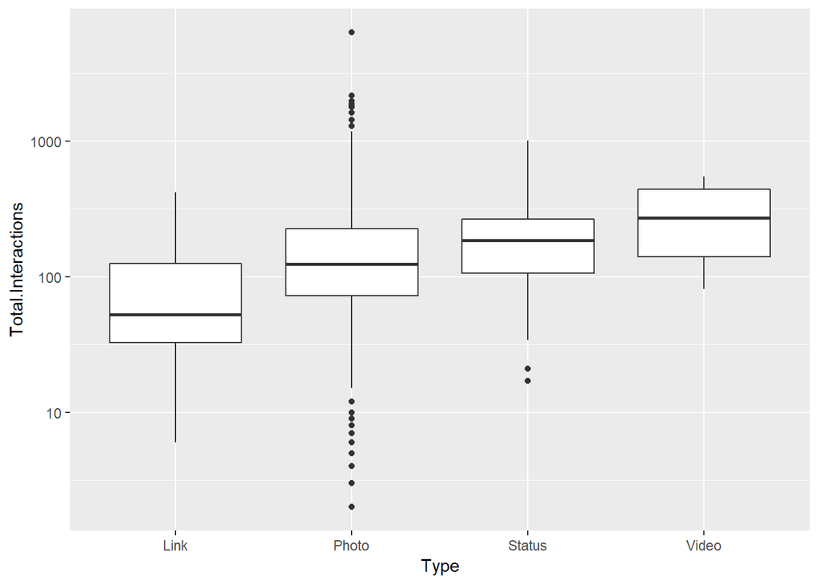

```r
ggplot(data) +
  aes(x = Type, y = Total.Interactions) +
  geom_boxplot() +
  scale_y_log10()
```

Here we create another ggplot boxplot of total interactions by day. We again use a log10 scale for the y-axis and reorder the days for the x-axis.

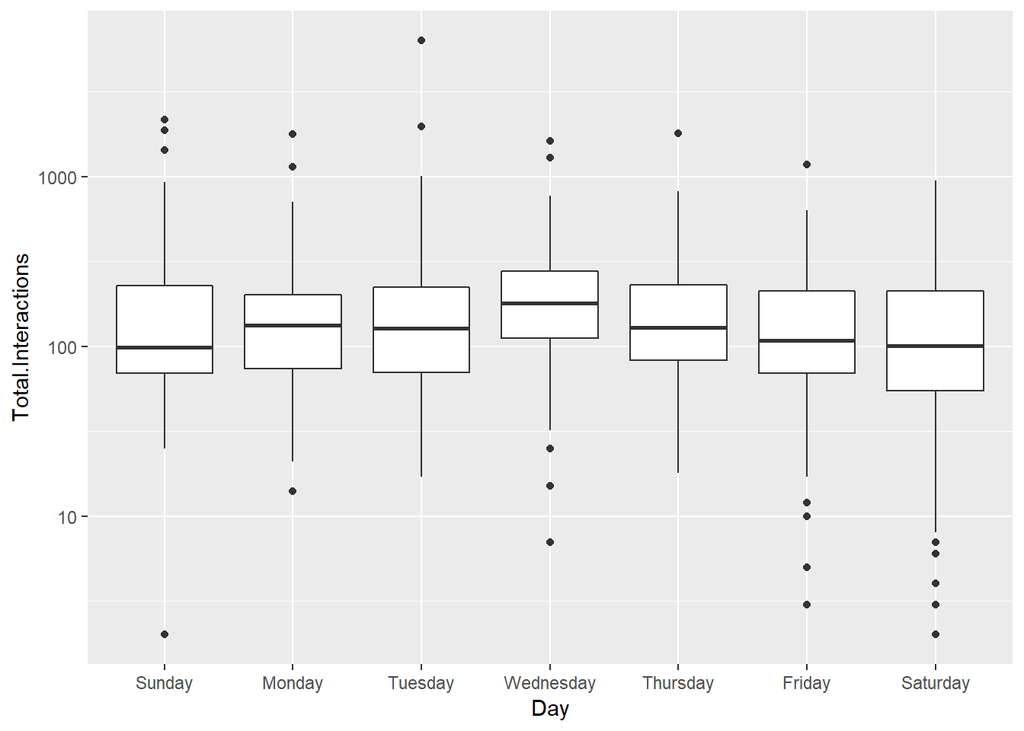

```r
data$Day <- factor(data$Day, levels = days_of_week, ordered = TRUE)

ggplot(data) +
  aes(x = Day, y = Total.Interactions) +
  geom_boxplot() +
  scale_y_log10()
```

## Data analysis

Here we test to see if there is a significant difference in total interactions based on whether the posts were paid or not.

```r
# Convert Paid into a categorical variable
data$Paid <- factor(data$Paid)
levels(data$Paid) <- c("not paid", "paid")

paid_interactions <- data %>% filter(Paid == "paid") %>% select(Total.Interactions)
unpaid_interactions <- data %>% filter(Paid == "not paid") %>% select(Total.Interactions)
t.test(paid_interactions, unpaid_interactions)
```

```
##
##  Welch Two Sample t-test
##
## data:  paid_interactions and unpaid_interactions
## t = 1.754, df = 157.37, p-value = 0.08138
## alternative hypothesis: true difference in means is not equal to 0
## 95 percent confidence interval:
##  -11.52107 194.27595
## sample estimates:
## mean of x mean of y
##  278.2302  186.8528
```

Based on the test results, there is not enough evidence to suggest there is a significant difference between the average total interactions of paid and unpaid posts using a significance level of 0.05. (p-value > 0.05)

Now we will create a boxplot of total interactions by whether the posts were paid or not to get a better look.

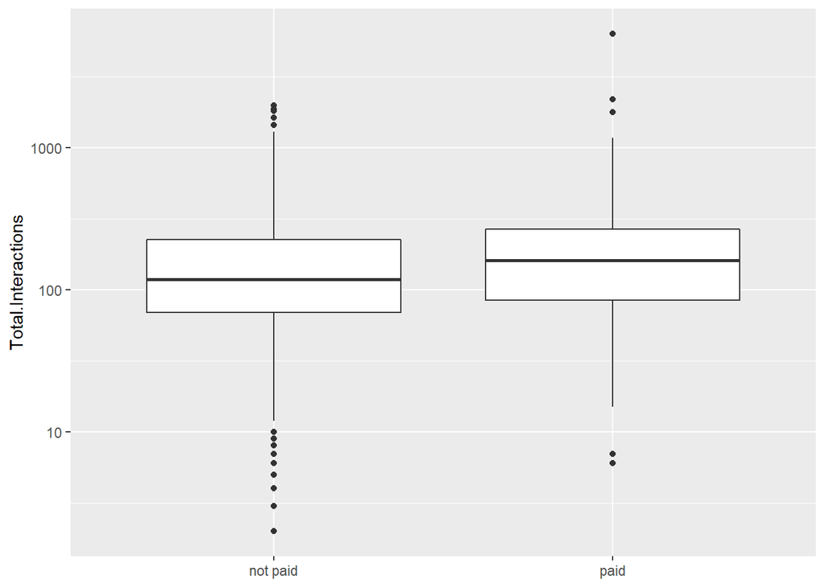

```r
# Do not plot NA values
ggplot(subset(data, !is.na(Paid))) +
  aes(x = Paid, y = Total.Interactions) +
  geom_boxplot() +
  scale_y_log10() +
  theme(axis.title.x = element_blank())
```